# Exploratory Data Analysis of the Red Wine Quality Dataset by *Tianzhixi Yin*

I plot the following figures to see if I can find out interesting interaction effects between features. Since all the explanatory variables are continous, this attempt is not very successful.

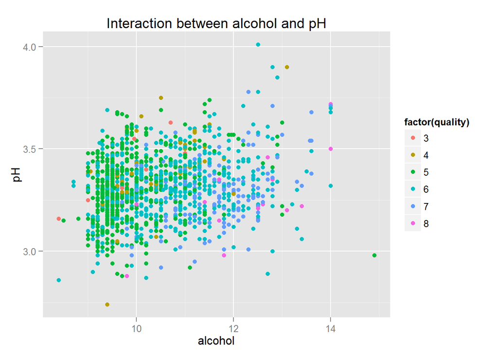

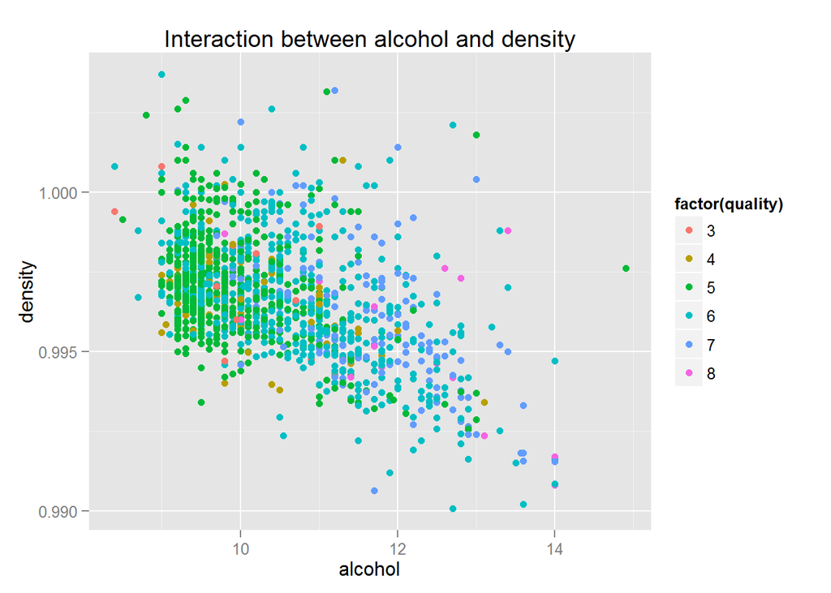

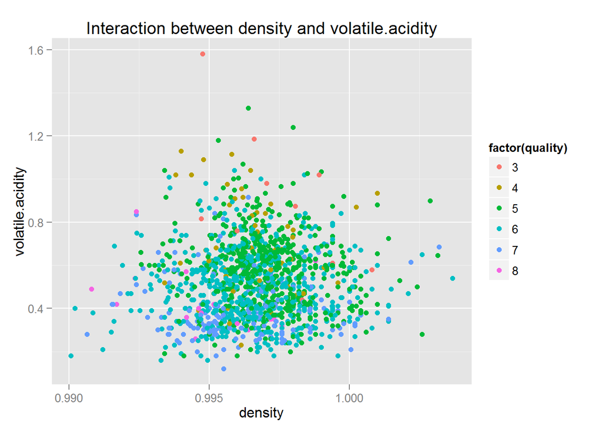

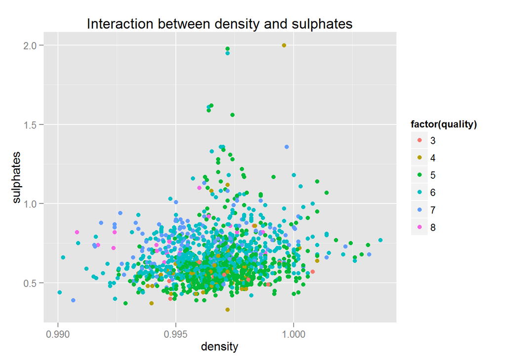

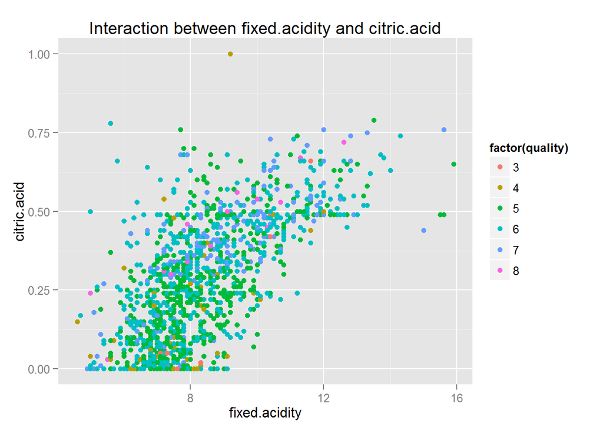

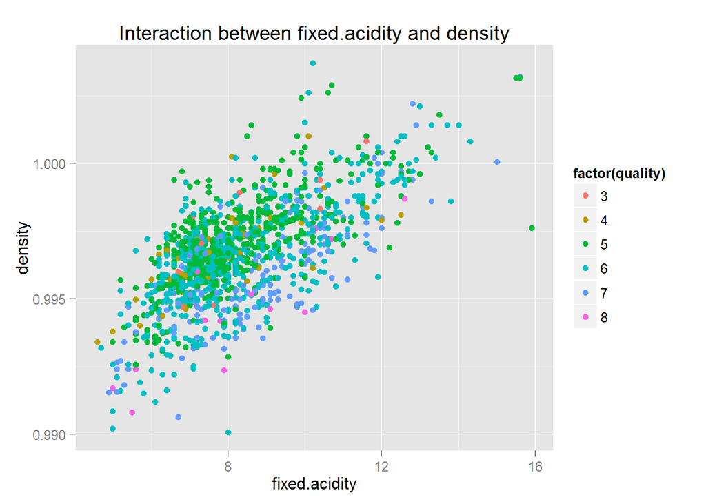

# Multivariate Analysis

### Talk about some of the relationships you observed in this part of the investigation. Were there features that strengthened each other in terms of looking at your feature(s) of interest?

It is not easy to find the features that strengthened each other in terms of looking at *quality* because all the explanatory variables are continuous. I tried to investigate several plots that might reveal some multivariate relationships but was not very successful.

### Were there any interesting or surprising interactions between features?

I found no strong interaction that could be important in predicting wine quality. However, one or two multivariate plots provide somewhat interesting patterns. For example, when I plot the relationship between *alcohol* and *pH* coloured by *quality*, I can see most good wine appear in the right-bottom part of the figure, which means higher *alcohol* and lower *pH* might be a good combination for wine. Also, when I plot the relationship between *density* and *volatile.acidity* coloured by *quality*, I can see most good wine appear in the left-bottom part of the figure, which means lower *density* and lower *volatile.acidity* might be another good combination.

### OPTIONAL: Did you create any models with your dataset? Discuss the strengths and limitations of your model.

```
## Call:
## polr(formula = as.factor(quality) ~ ., data = wine, Hess = TRUE)
##
## Coefficients:
##                          Value Std. Error t value
## fixed.acidity          0.10240   0.051209   2.000
## volatile.acidity      -3.41794   0.400103  -8.543
## citric.acid           -0.80494   0.462371  -1.741
## residual.sugar         0.07617   0.038210   1.993
## chlorides             -5.17121   1.354373  -3.818
## free.sulfur.dioxide    0.01392   0.006767   2.057
## total.sulfur.dioxide  -0.01119   0.002360  -4.744
## density              -48.92546   0.974488 -50.206
## pH                    -0.98472   0.496900  -1.982
## sulphates              2.86724   0.358016   8.009
## alcohol                0.85611   0.059355  14.424
##
## Intercepts:
##     Value    Std. Error t value
## 3|4 -48.8787   0.9979   -48.9797
## 4|5 -46.9597   0.9959   -47.1541
## 5|6 -43.2452   0.9988   -43.2968
## 6|7 -40.3898   1.0111   -39.9454
## 7|8 -37.3837   1.0409   -35.9138
##
## Residual Deviance: 3074.928
## AIC: 3106.928
```

```
## Start:  AIC=3106.93
## as.factor(quality) ~ fixed.acidity + volatile.acidity + citric.acid +
##     residual.sugar + chlorides + free.sulfur.dioxide + total.sulfur.dioxide +
##     density + pH + sulphates + alcohol
##
##                        Df    AIC
## - density               1 3106.0
## <none>                    3106.9
## - fixed.acidity         1 3107.2
## - pH                    1 3107.8
## - citric.acid           1 3107.9
## - residual.sugar        1 3108.1
## - free.sulfur.dioxide   1 3108.9
## - chlorides             1 3119.7
## - total.sulfur.dioxide  1 3127.8
## - sulphates             1 3171.1
## - volatile.acidity      1 3178.7
## - alcohol               1 3203.5
##
## Step:  AIC=3106.01
## as.factor(quality) ~ fixed.acidity + volatile.acidity + citric.acid +
##     residual.sugar + chlorides + free.sulfur.dioxide + total.sulfur.dioxide +
##     pH + sulphates + alcohol
##
##                        Df    AIC
## - fixed.acidity         1 3105.2
## <none>                    3106.0
## - residual.sugar        1 3106.1
## + density               1 3106.9
## - citric.acid           1 3107.0
## - free.sulfur.dioxide   1 3108.6
## - pH                    1 3110.3
## - chlorides             1 3119.6
## - total.sulfur.dioxide  1 3128.1
## - sulphates             1 3169.5
## - volatile.acidity      1 3181.3
## - alcohol               1 3358.4
##
## Step:  AIC=3105.22
## as.factor(quality) ~ volatile.acidity + citric.acid + residual.sugar +
```

[output cut: 38 more lines]

```
##     total.sulfur.dioxide + pH + sulphates + alcohol
##
##                        Df    AIC
## <none>                    3104.8
## + residual.sugar        1 3105.1
## + citric.acid           1 3105.5
## + fixed.acidity         1 3106.7
## + density               1 3106.8
## - free.sulfur.dioxide   1 3109.7
## - pH                    1 3115.4
## - chlorides             1 3123.6
## - total.sulfur.dioxide  1 3133.6
## - sulphates             1 3168.1
## - volatile.acidity      1 3190.8
## - alcohol               1 3361.8
```

```
## Call:
## polr(formula = as.factor(quality) ~ volatile.acidity + chlorides +
##     free.sulfur.dioxide + total.sulfur.dioxide + pH + sulphates +
##     alcohol, data = wine, Hess = TRUE)
##
## Coefficients:
##                         Value Std. Error t value
## volatile.acidity     -3.06980   0.332708  -9.227
## chlorides            -5.77802   1.290679  -4.477
## free.sulfur.dioxide   0.01737   0.006646   2.613
## total.sulfur.dioxide -0.01223   0.002259  -5.416
## pH                   -1.31167   0.371433  -3.531
## sulphates             2.78398   0.354651   7.850
## alcohol               0.88355   0.057978  15.239
##
## Intercepts:
##     Value   Std. Error t value
## 3|4 -1.6369  1.3043    -1.2550
## 4|5  0.2798  1.2701     0.2203
## 5|6  3.9810  1.2677     3.1403
## 6|7  6.8305  1.2788     5.3414
## 7|8  9.8344  1.3060     7.5299
##
## Residual Deviance: 3080.848
## AIC: 3104.848
```

I think an ordinal logistic regression model should be appropriate for this type of data. I first fit all the features and do variable selection based using stepwise method to obtain a reduced model. The strength for this model is that it can predict ordinal response and the reduced model is fairly simple to interpret. One limitation of the model is that it cannot predict values 0, 1, 2, 9, and 10 for quality. That is because we do not have such observations in our data. So the model is not good for predicting very good or very bad wine. Another limitation could be since not many explanatory variables are good at explaining the wine quality, this model might not be good in prediction generally.

# Final Plots and Summary

### Plot One

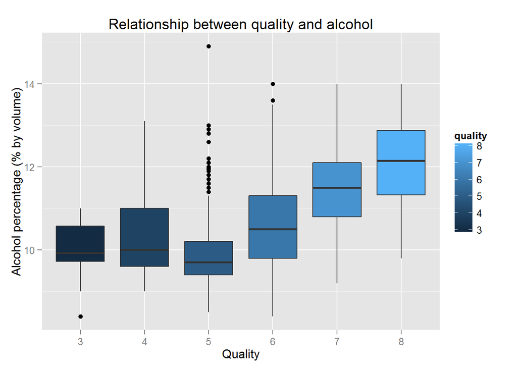

### Description One

The relationship between wine quality and the percent alcohol content of the wine. We can see there is a general increasing trend for quality when the percentage of alcohol increases. Though this trend is not clear for wines with low quality (3, 4 ,5). The correlation value between the two is 0.476.

### Plot Two

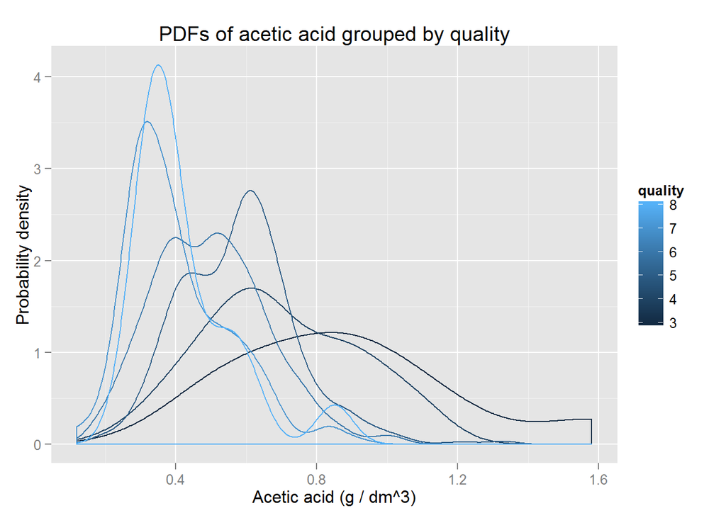

### Description Two

The relationship between wine quality and the amount of acetic acid in wine. The y axis is the probability density of acetic acid. We can see high quality wines have normal distributions peaked around low acetic acid, while low quality wines have much flat distributions that are centered around medium acetic acid. High acetic acid leads only to bad wine. The correlation value between the two is -0.391.

### Plot Three

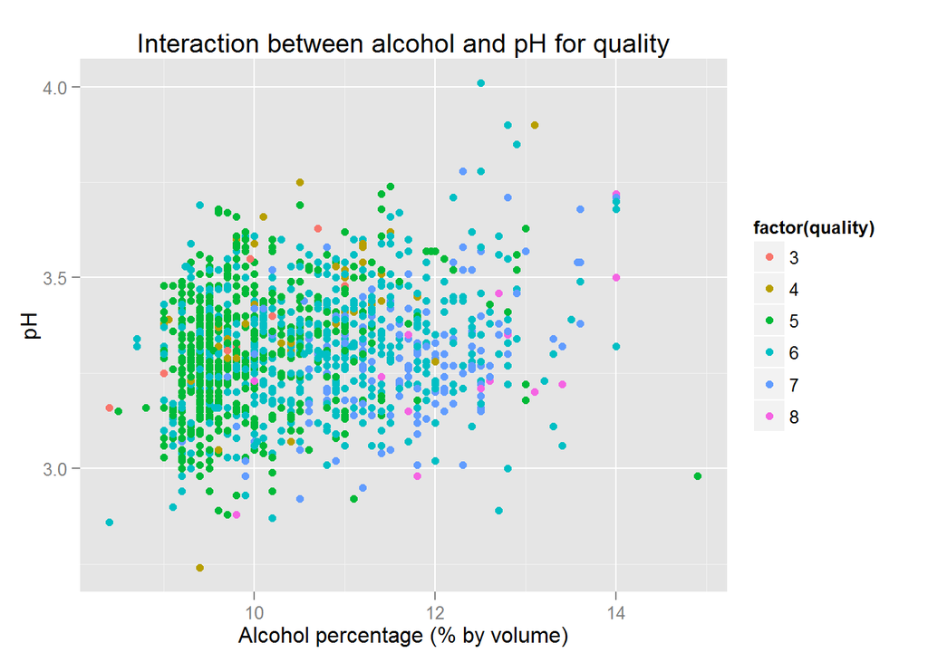

### Description Three

This is a plot trying to find out whether there is an interaction effect between *alcohol* and *pH* for *quality*. The answer is not really. However, we can see that high *alcohol* and low *pH* tend to produce good wines more often than bad wines, though this pattern is not very strong.

# Reflection

In this exploratory data analysis, I can see that most wines are of medium quality and most explanatory variables follow certain distributions without too many outliers. The data are fairly clean and not very problematic. The response variable *quality* is an ordered factor, while all the independent variables are continuous according to various magnitudes.

My main struggles include: there are no explanatory variables that are highly correlated with *quality*, most of them show no trend in terms of *quality*. Still, the relationships between *quality* and *alcohol*, *quality* and *volatile.acidity* are quite interesting and reveal certain attributes of good wines. There are several explanatory variables correlated with each other, for example *fixed.acidity* and *pH*, *free.sulfur.dioxide* and *total.sulfur.dioxide*. But the correlations altogether are not strong enough for consideration about multicollinearity. Another struggle is that interaction effects are not that obvious within this dataset, especially since all the explanatory variables are continuous, either by plotting or modeling I could not find a meaningful interaction to display. However, a few somewhat interesting interactions were found in the multivariate plotting section, although those interaction effects are not very strong.

I think an ordinal logistic regression should suffice for the general purpose of understanding important features and predicting quality. But since the relationship between quality and other features are not very strong, the model might not be very good for prediction.

In the future, maybe we can explore other types of wine than just the Portuguese “Vinho Verde” wine, because a single type of wine might cause bias in accessing the common attributes of good wine and what cause it. If we get more data, maybe we can find stronger relationship between wine quality and other features. If we gather some categorical features, maybe we will find interesting interaction effects within the features that explain wine quality.